# Ch7 R Graphics

Sejin Park

2016 10 22

## Lattice

Graph package for Trellis

### Trellis

- Bill Cleveland
- multipanel conditioning for categorical variable

## Dataset : autompg

398대의 자동차 연비

### 변수 설명

- mpg:연비
- cylinder : 실린더수
- displacement : 배기량
- horsepower : 마력
- weight : 무게
- acceleration : 가속능력
- year : 연도
- origin : 만들어진 곳
- name : 차종

```r
autompg <- read.csv("data/auto-mpg.csv", header = TRUE, na.string = ".")
dim(autompg)
```

```
## [1] 398   9
```

```r
head(autompg)
```

```
##   mpg cylinder displacement horsepower weight acceleration year origin
## 1  18        8          307        130   3504         12.0   70      1
## 2  15        8          350        165   3693         11.5   70      1
## 3  18        8          318        150   3436         11.0   70      1
## 4  16        8          304        150   3433         12.0   70      1
## 5  17        8          302        140   3449         10.5   70      1
## 6  15        8          429        198   4341         10.0   70      1
##                        name
## 1 chevrolet chevelle malibu
## 2         buick skylark 320
## 3        plymouth satellite
## 4             amc rebel sst
## 5               ford torino
## 6          ford galaxie 500
```

## Dataset : tipping

### tipping 자료

레스토랑 고객들의 팁에 대한 습성을 알아보기 위하여 미국 뉴욕 근교에서 수집된 자료

### 변수 설명

- obs : 관측번호
- totbill : 전체 가격
- tip : 팁
- sex : 계산한 사람의 성별
- smoker : 흡연석/금연석
- day : 요일
- time : 점심/저녁
- size : 일행수
- tiprate = tip/totbill*100 전체가격에 대한 팁의 비율

```r
tipping <- read.csv("./data/tips.csv", header = TRUE)
tipping$tiprate <- tipping$tip/tipping$totbill*100
dim(tipping)
```

```
## [1] 244   9
```

```r
head(tipping)
```

```
##   obs totbill  tip    sex     smoker day   time size   tiprate
## 1   1   16.99 1.01 Female Non-smoker Sun Dinner    2  5.944673
## 2   2   10.34 1.66   Male Non-smoker Sun Dinner    3 16.054159
## 3   3   21.01 3.50   Male Non-smoker Sun Dinner    3 16.658734
## 4   4   23.68 3.31   Male Non-smoker Sun Dinner    2 13.978041
## 5   5   24.59 3.61 Female Non-smoker Sun Dinner    4 14.680765
## 6   6   25.29 4.71   Male Non-smoker Sun Dinner    4 18.623962
```

## Lattice : Graph for One variable

### 막대그래프

범주형 변수의 각 범주에 대한 도수를 막대그림으로 나타낸 것 barchart 함수를 이용 문자형 또는 factor 변수를 이용

기본형 = 가로형 막대 그림

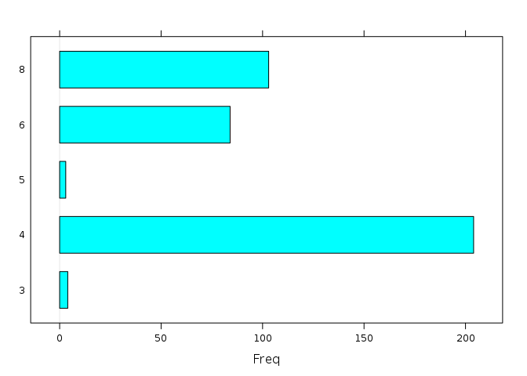

```r
library(lattice)
barchart(as.factor(autompg$cylinder))
```

세로형 막대그래프 horizontal = FALSE 옵션 사용

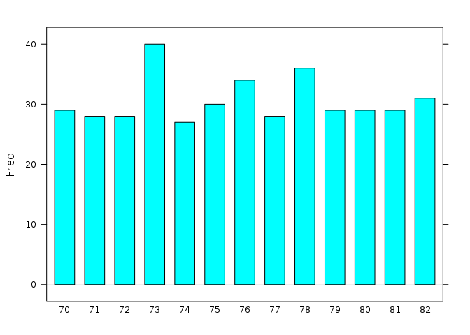

```r
barchart(as.factor(autompg$year), horizontal = FALSE)
```

### Histogram

연속자료의 분포를 쉽게 파악하기 위하여 그리는 그림 histogram() 숫자 변수 이용

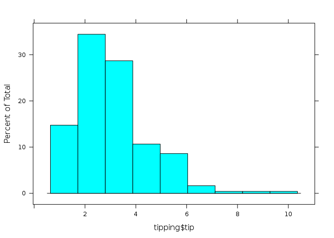

```r
histogram(tipping$tip)
```

breaks 옵션을 이용하여 binwidth 설정 main 옵션을 이용하여 그림의 title 지정

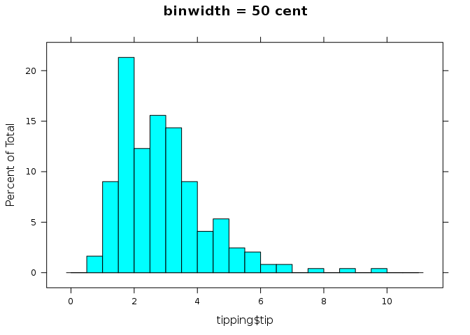

```r
histogram(tipping$tip, breaks = seq(0,11,0.5), main = "binwidth = 50 cent")
```

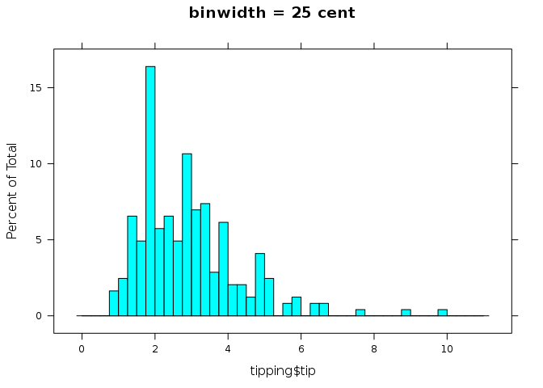

```r
histogram(tipping$tip, breaks = seq(0,11,0.25), main = "binwidth = 25 cent")
```

binwidth 를 달리하면 다른 패턴을 발견할 수 있다.

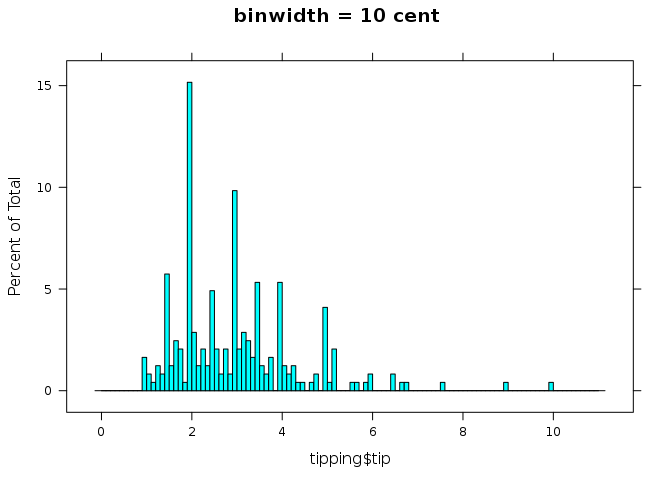

```r
histogram(tipping$tip, breaks = seq(0,11,0.1), main = "binwidth = 10 cent")
```

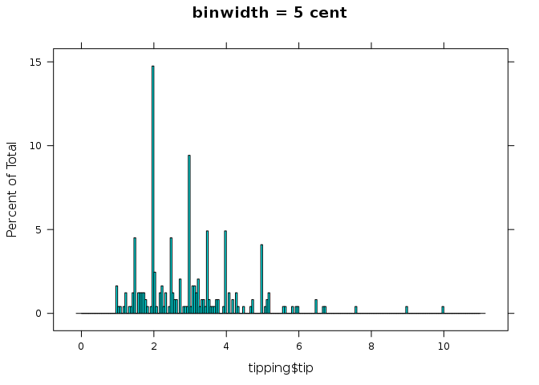

```r
histogram(tipping$tip, breaks = seq(0,11,0.05), main = "binwidth = 5 cent")
```

### 밀도 그림

- 연속자료의 분포를 파악하기 위해 그린 그림 density 함수 이용 xlab 옵션을 이용하여 X축 레이블 지정

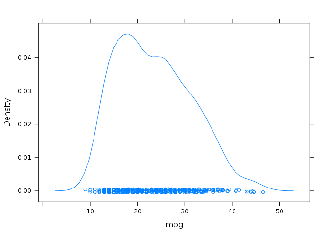

```r
densityplot(autompg$mpg, xlab="mpg")
```

## Lattice : Graph for Two variable

### Continuous vs Continuous

- scatter plot : 2 continuous variable
- xyplot()
- " y ~ x"

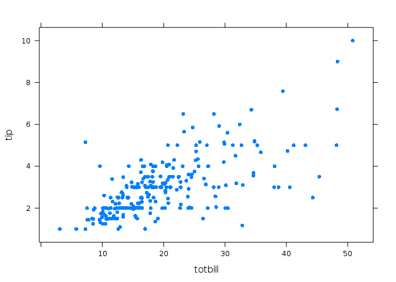

```r
xyplot(tip ~ totbill, pch = 16, data = tipping)
```

" y ~ x | categorical variable"

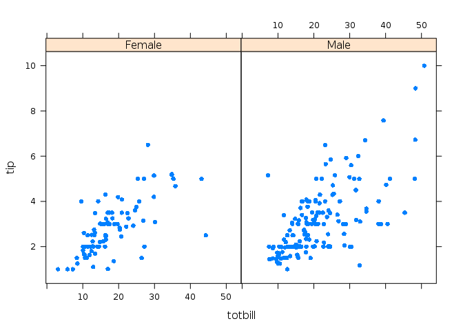

```r
xyplot(tip ~ totbill | sex, pch = 16, data = tipping)
```

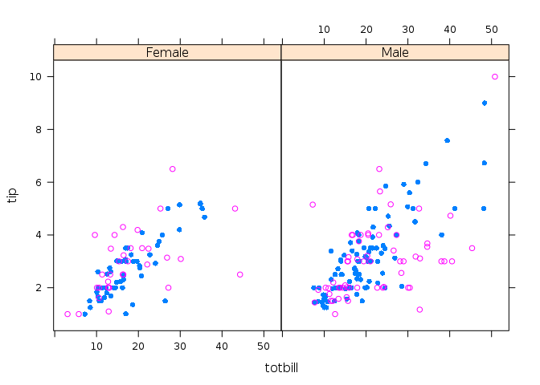

```r
xyplot(tip ~ totbill | sex, group = smoker, pch = c(16, 1), data = tipping)
```

### panel

- panel.grid
- “h = -1” 수평으로 각 눈금마다 눈금선 넣기
- “v = 2” 수직으로 2개 눈금선 넣기
- panel.xyplot()
- “pch = 16” (*)
- panel.lmline

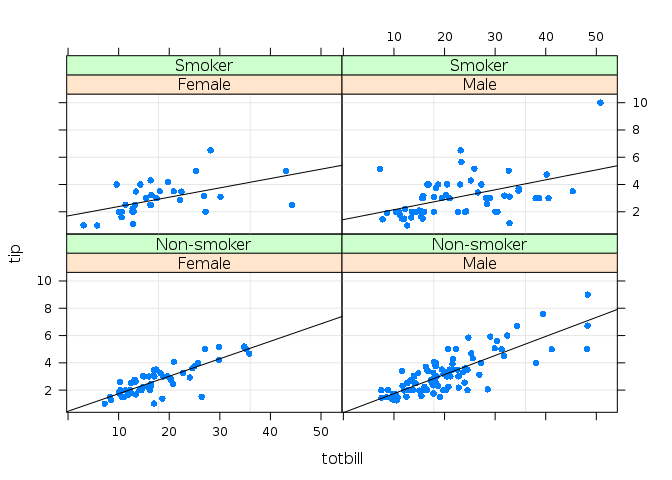

```r
xyplot(tip ~ totbill | sex + smoker,
  data = tipping,
  panel = function(x, y){
   panel.grid(h = -1, v = 2)
   panel.xyplot(x,y,pch=16)
   panel.lmline(x,y)
  })
```

## Continuous vs Categorical

### boxplot : 각 범주별로 연속변수의 분포를 비교

bwplot()

- 기본 : 가로
- horizontal = FALSE : 세로

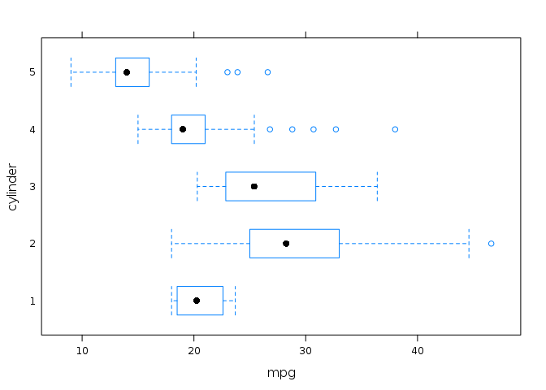

```r
bwplot(cylinder ~ mpg, data = autompg)
```

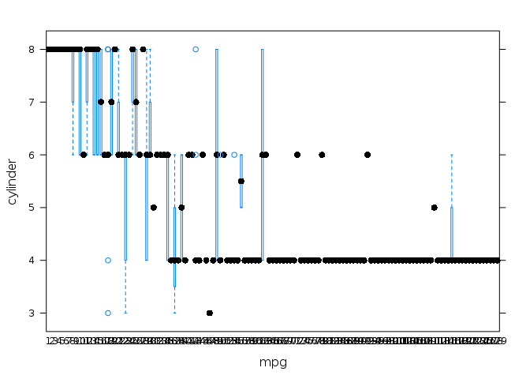

```r
bwplot(cylinder ~ mpg, data = autompg, horizontal = FALSE)
```

### dotplot

dotplot()

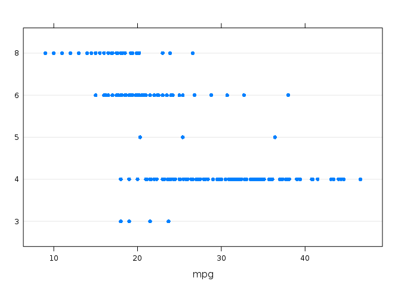

```r
dotplot(as.factor(cylinder)~mpg, data = autompg)
```

## Categorical vs Categorical

- mosaic 그림 : 이차원 분할표로 정리된 자료에서 범주형 변수 중 하나의 변수를 조건으로 나머지 변수의 분포를 나타내는 그림
- Trellis 형태의 mosaic 그림은 vcd 패키지에서 mosaic 함수로 제공 - ’~ A + B’의 식에서는 A변수를 조건으로 A변수의 각 범주 내에서 B 변수의 범주비율을 그림으로 나타냄

mosaic()

```r
library(vcd)
```

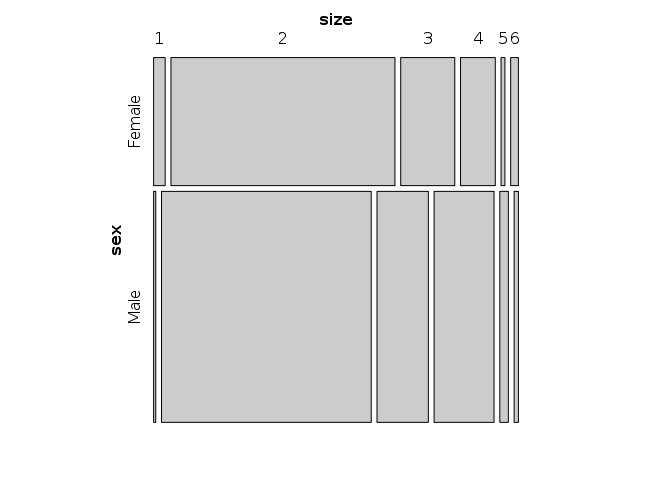

```r
mosaic( ~ sex + size, data =tipping)
```

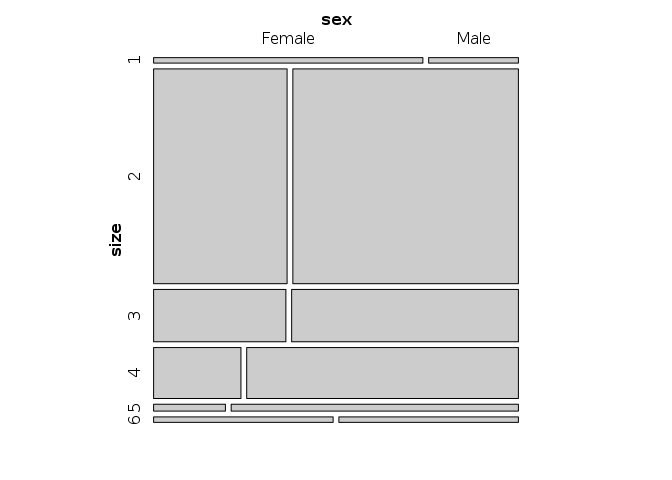

```r
mosaic( ~ size + sex, data =tipping)
```

cotabplot()

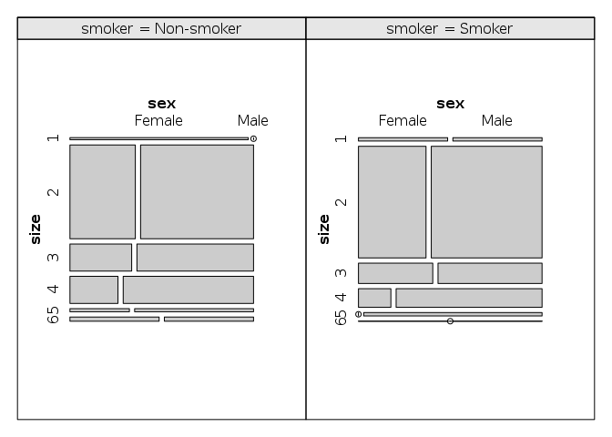

```r
cotabplot( ~ size + sex | smoker, data = tipping, panel = cotab_mosaic)
```

## multivariate

여러개의 연속변수를 동시에 살펴보기 위한 그림 두 연속변수씩 짝지어 그린 산점도를 행렬 형태로 나타낸 것 splom 함수를 이용하여 그림

autompg[, c(1,3:6)] 연속형 변수만 선택

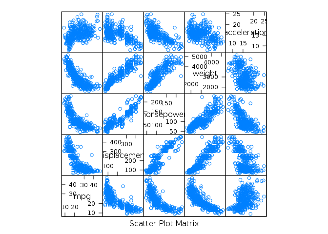

```r
splom(~autompg[,c(1,3:6)], data = autompg)
```

group, pch, col 등의 옵션으로 점의 모양, 색깔을 그룹별로 지정 key 옵션을 이용하여 범례 내용을 명시

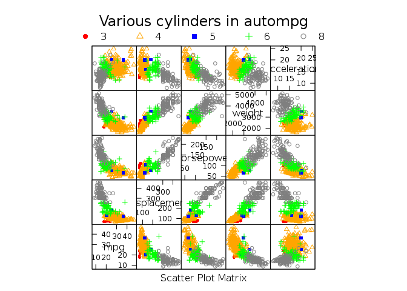

```r
splom(~autompg[c(1,3:6)], groups = cylinder , data = autompg,
  col = c("red", "orange", "blue", "green", "grey50"),
  pch = c(16,2,15,3,1), cex = 0.7,
  key = list(title = "Various cylinders in autompg",
     columns = 5,
     points = list(pch = c(16, 2, 15, 3, 1),
        col = c("red", "orange", "blue", "green","grey50")),
     text = list(c("3","4","5","6","8"))))
```

### paralleplot

연속변수의 수가 많아 산점도 행렬로 파악이 힘든 경우 이용 parallelplot() 기본 수평, horizontal = FALSE 수직

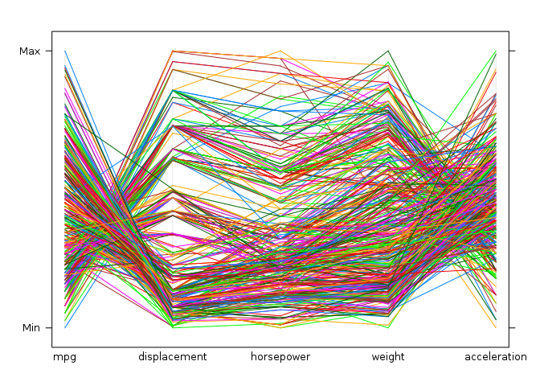

```r
parallelplot(~ autompg[,c(1,3:6)], data = autompg, horizontal = FALSE)
```

조건식을 이용 여러 그룹별로 평행좌표 그림 따로 그려 비교

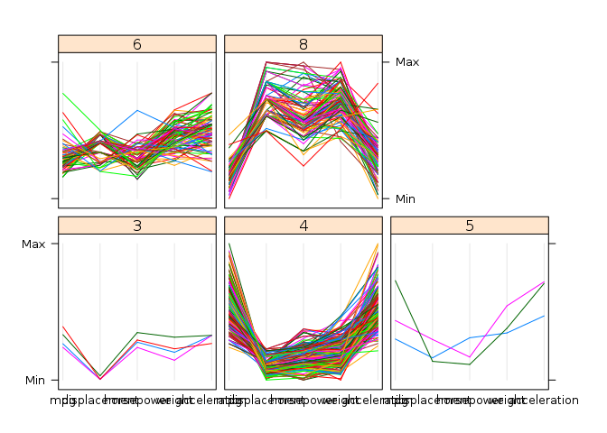

```r
parallelplot(~ autompg[,c(1,3:6)] | as.factor(cylinder), data = autompg, horizontal = FALSE)
```

## 3D scatter plot

- 연속변수가 3개인 경우 3차원 상에서의 자료분포를 알아보기 위한 그림
- cloud 함수를 이용, ’Z ~ X*Y’ 형태의 식으로 이용

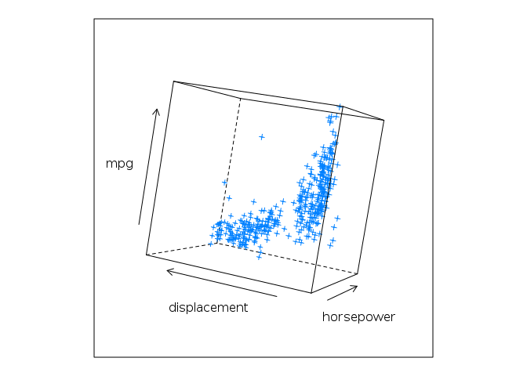

```r
cloud(mpg~horsepower*displacement, data = autompg,
  screen = list(x=-80, y=70))
```

## Grammer of Graphics

2005 Wilkinson Layered grammar of graphics

- ggplot2
- qplot, ggplot

## DATATSET : abalone

- 전복의 나이를 예측하기 위하여 성별, 길이, 무게 등을 측정한 자료 ### 변수 설명
- sex : 수컷(M), 암컷(F), 유아기(I)
- height : 껍질 안의 몸통 길이
- diameter : length에 수직인 길이
- shuckedW : 껍질을 제외한 무게
- wholeW : 전체 무게
- shellW : 껍질 무게
- visceraW : 내장 무게
- rings ; 링의 수(나이를 나타냄)
- length : 껍질 중 가장 긴 부분의 길이

```r
abalone <- read.csv("data/abalone.csv", header = TRUE)
dim(abalone)
```

```
## [1] 4177    9
```

```r
head(abalone)
```

```
##   sex length diameter height wholeW shuckedW visceraW shellW rings
## 1   M  0.455    0.365  0.095 0.5140   0.2245   0.1010  0.150    15
## 2   M  0.350    0.265  0.090 0.2255   0.0995   0.0485  0.070     7
## 3   F  0.530    0.420  0.135 0.6770   0.2565   0.1415  0.210     9
## 4   M  0.440    0.365  0.125 0.5160   0.2155   0.1140  0.155    10
## 5   I  0.330    0.255  0.080 0.2050   0.0895   0.0395  0.055     7
## 6   I  0.425    0.300  0.095 0.3515   0.1410   0.0775  0.120     8
```

## DATATSET : Pconsump

2006년 12월부터 2010년 11월까지 47개월간 프랑스의 한 지역에서 수집된 원 자료 중 2006년 12월 17일, 18일, 그리고 2007년 12월 17일, 18일을 추출한 자료

### 변수 설명

- Date : 날짜
- Time : 시간
- X1 : 평균 유효전력
- X2 : 평균 무효전력
- X3 : 평균 전압
- X4 : 전류 강도
- X5 : 보조계량기1
- X6 : 보조계량기2
- X7 : 보조계량기3

```r
Pconsump <- read.csv("data/power_consumption.csv")
dim(Pconsump)
```

```
## [1] 5760    9
```

```r
head(Pconsump)
```

```
##         Date    Time    X1    X2     X3   X4 X5 X6 X7
## 1 17/12/2006 0:00:00 1.044 0.152 242.73  4.4  0  2  0
## 2 17/12/2006 0:01:00 1.520 0.220 242.20  7.4  0  1  0
## 3 17/12/2006 0:02:00 3.038 0.194 240.14 12.6  0  2  0
## 4 17/12/2006 0:03:00 2.974 0.194 239.97 12.4  0  1  0
## 5 17/12/2006 0:04:00 2.846 0.198 240.39 11.8  0  2  0
## 6 17/12/2006 0:05:00 2.848 0.198 240.59 11.8  0  1  0
```

## Scatterplot : qplot()

qplot(x,y,data= dataset)

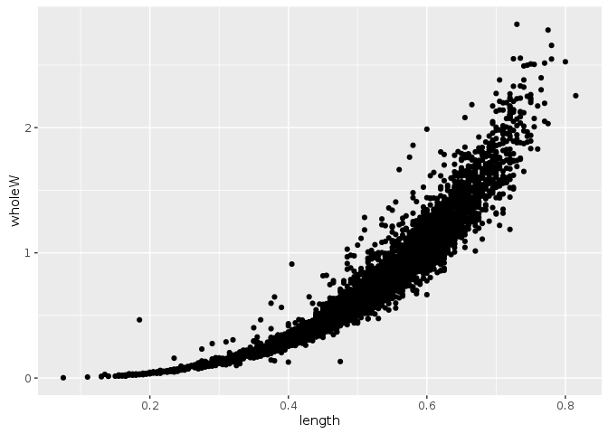

```r
library(ggplot2)
qplot(length, wholeW, data = abalone)
```

colour, shape

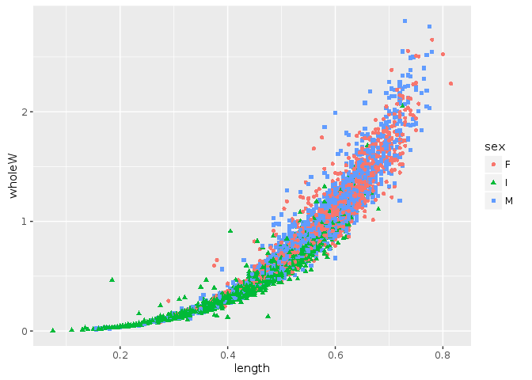

```r
qplot(length, wholeW, data = abalone, colour = sex, shape = sex)
```

alpha

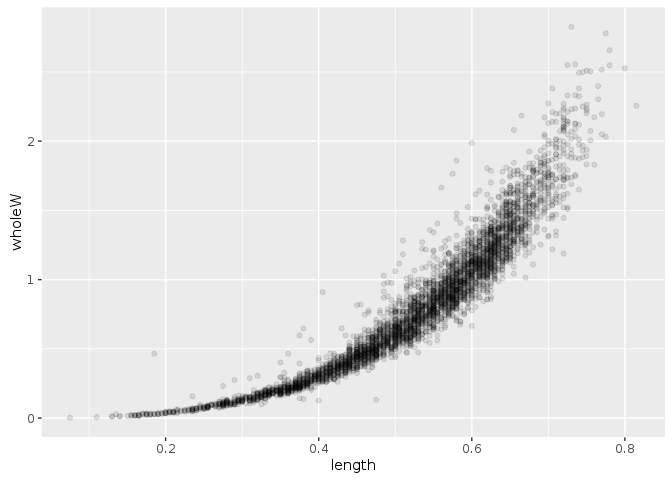

```r
qplot(length, wholeW, data = abalone, alpha=I(1/10))
```

geom = “boxplot” X : categorical variable

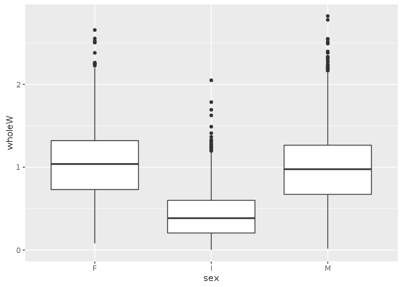

```r
qplot(sex, wholeW, data = abalone, geom = "boxplot")
```

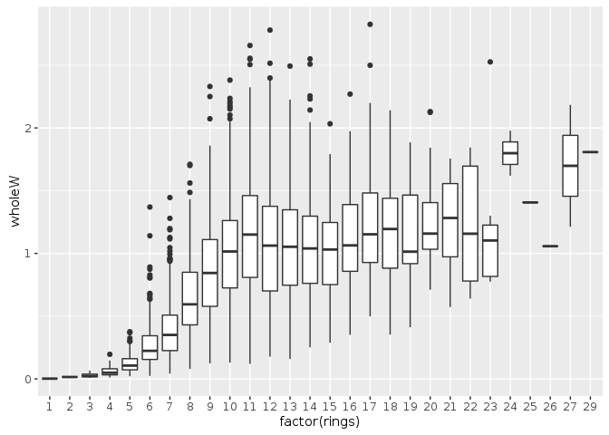

```r
qplot(factor(rings), wholeW, data = abalone, geom = "boxplot")
```

geom = jittering

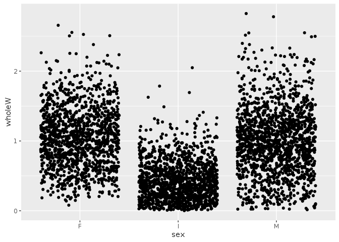

```r
qplot(sex, wholeW, data = abalone, geom = "jitter")
```

geom = jitter & alpha

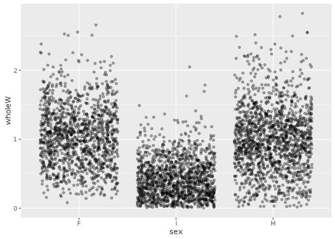

```r
qplot(sex, wholeW, data = abalone, geom = "jitter", alpha = I(1/3))
```

geom = “histogram” fill = categorical variable

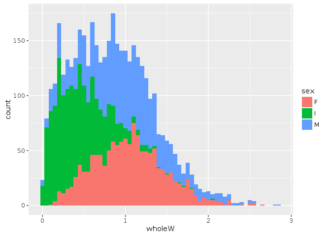

```r
qplot(wholeW, data = abalone, geom = "histogram", binwidth = 0.05, fill = sex)
```

facets = .~B

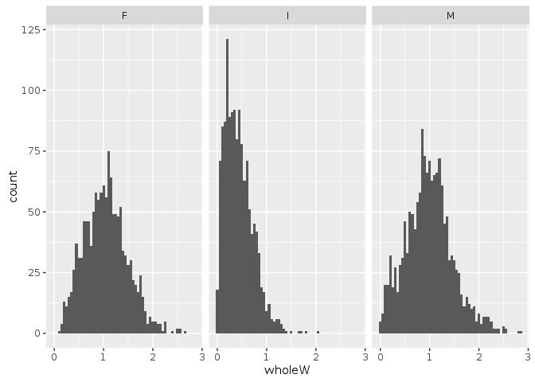

```r
qplot(wholeW, data = abalone, geom = "histogram", binwidth = 0.05, facets = .~sex)
```